# Transport trends and development in Switzerland

28 mai, 2018

## Introduction

## Initial Questions

- Where do we stand with green mobility in Switzerland ?
- Have awareness, scientific progress, bonus policies for ecological vehicles etc. really impacted our consumption of mobility?

## Data

We used data from the Office Fédéral de la Statistique (OFS) mainly :

- Road vehicle fleet by vehicle groups and vehicle types from 1990 to 2017 (retrieved from [OFS website (fr)](https://www.bfs.admin.ch/bfs/fr/home/statistiques/mobilite-transports/infrastructures-transport-vehicules/vehicules/vehicules-routiers-parc-taux-motorisation.assetdetail.4382325.html)). Cleaned up on excel
- Road vehicles put into circulation by vehicle groups and kinds from 1990 to 2017 (retrieve from [OFS website (fr)](https://www.bfs.admin.ch/bfs/fr/home/statistiques/mobilite-transports/infrastructures-transport-vehicules/vehicules/routiers-mises-circulation.assetdetail.4382276.html)). Cleanup on excel
- Transport of people: kilometric allowance and vehicules movement 2005 to 2016 (retrieve from [OFS website (fr)](https://www.bfs.admin.ch/asset/fr/je-f-11.04.01.01) and [ODS website (fr)](https://www.bfs.admin.ch/bfs/fr/home/statistiques/mobilite-transports/transport-personnes/prestations.assetdetail.4083125.html). Cleanup on excel

## Exploratory Analysis

## Part One: green mobility in Switzerland

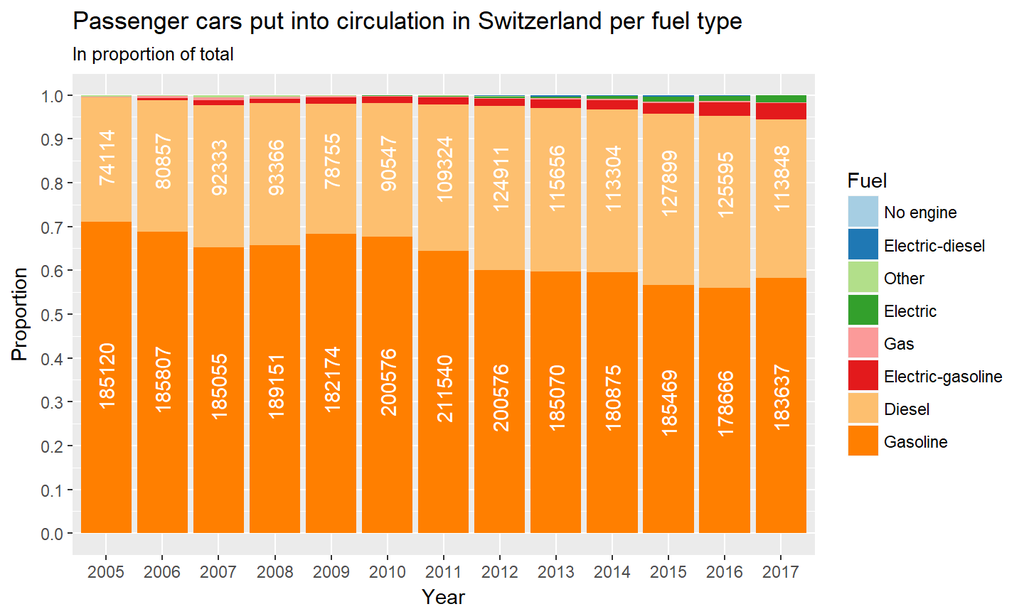

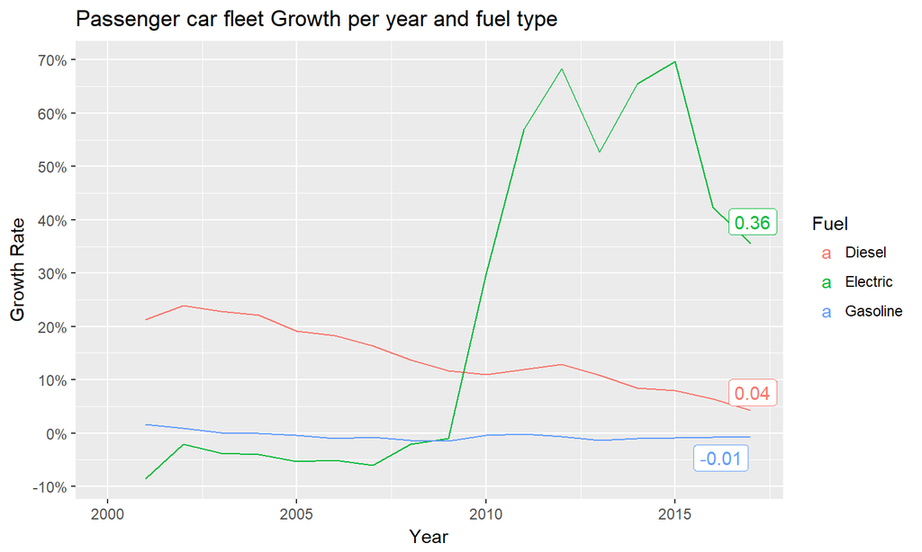

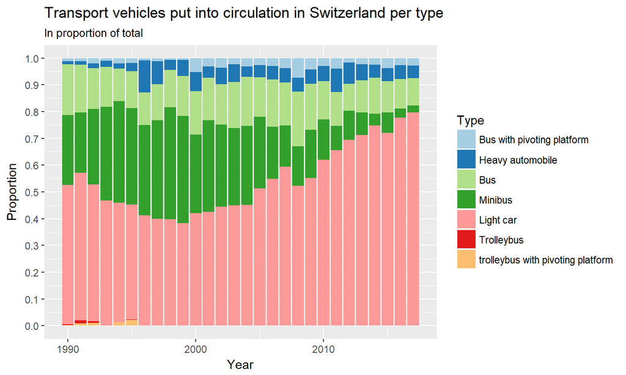

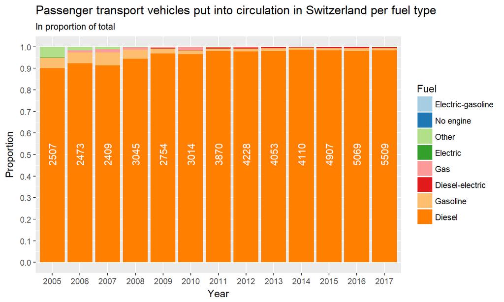

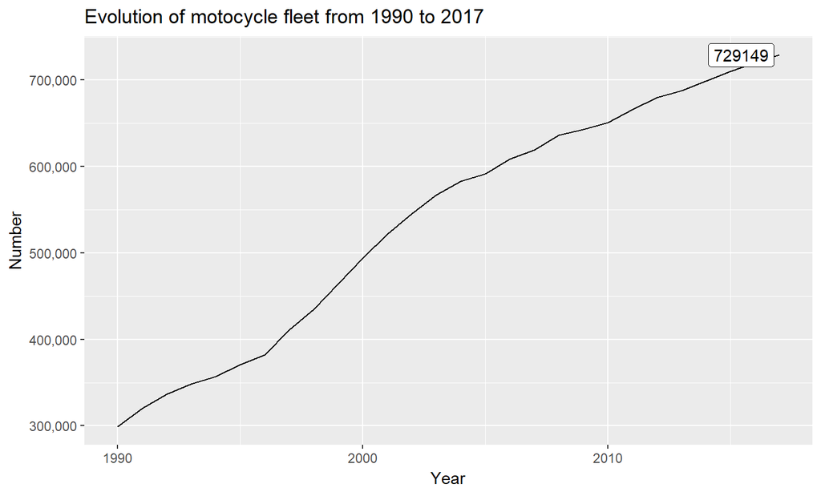

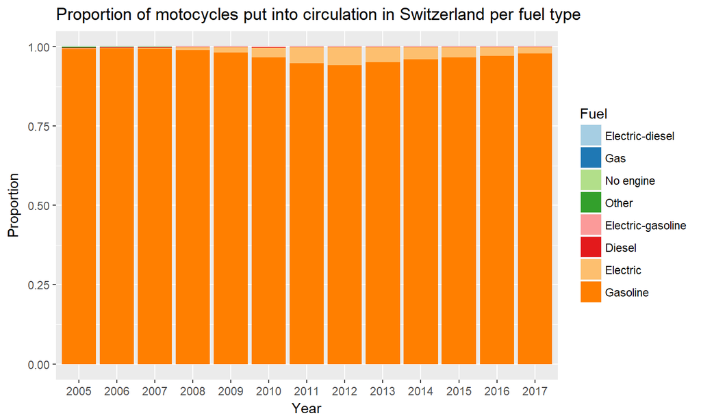

## Part Two: Difference between types of vehicules

Infrastructure and vehicule-kilometer

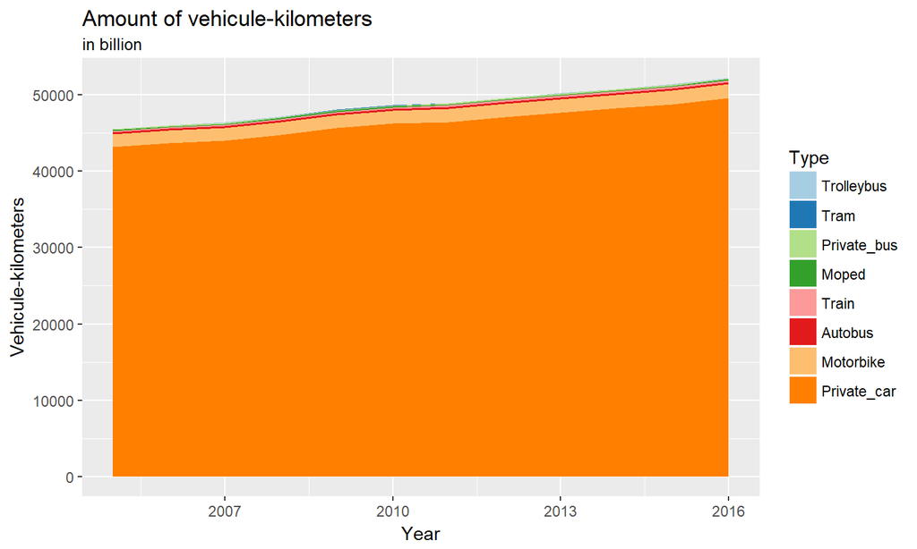

## Increase of the tranportation types

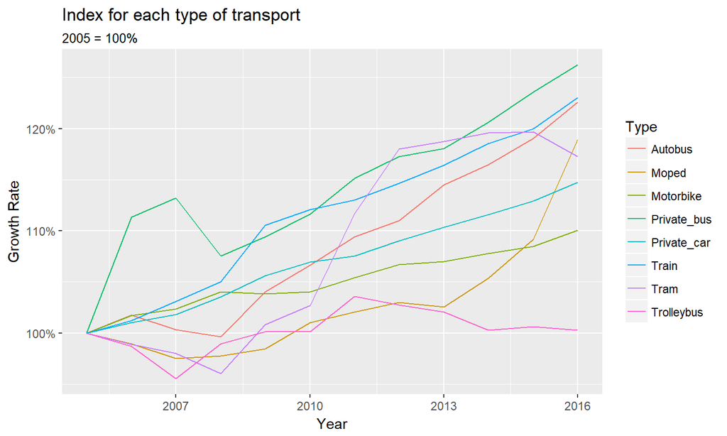

## People in Switzerland always travel more

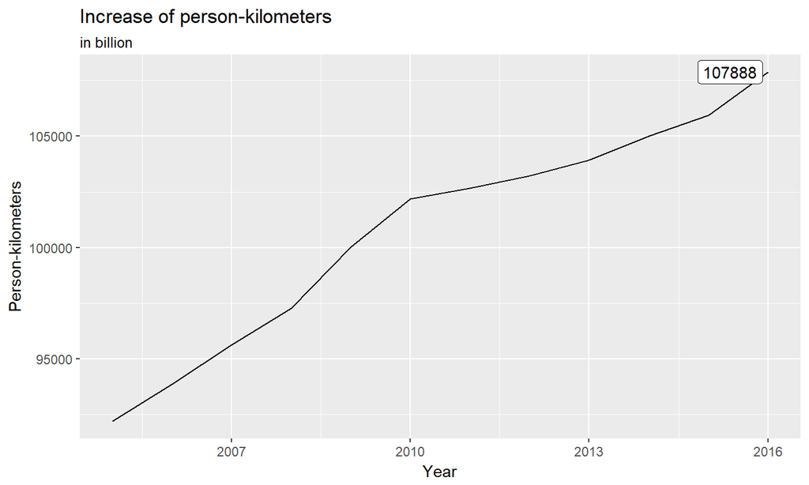

## Behaviour and person-kilometer

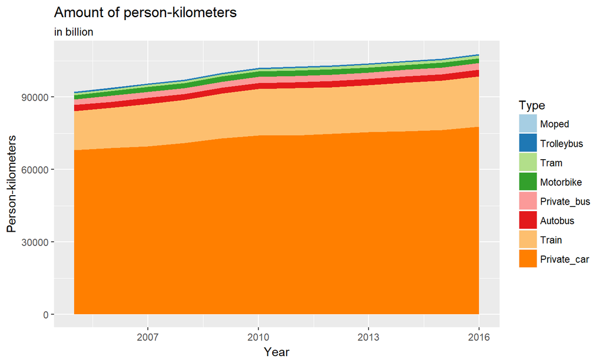

## Increase of the tranportation types

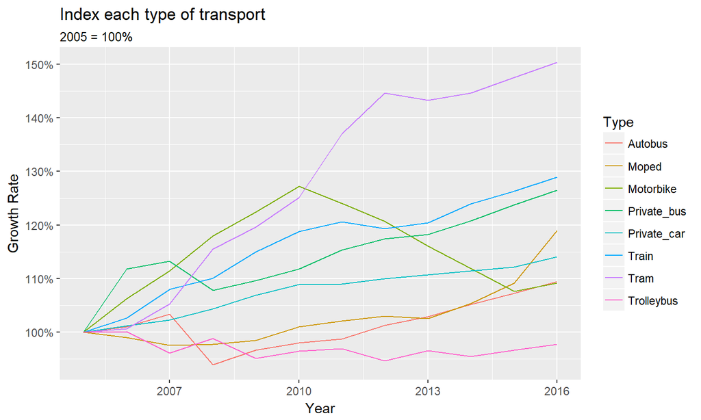